# R Notebook

```r
gd2 = gd2 %>% group_by(sample) %>%
mutate(sample_count = n()) %>%
ungroup() %>% filter(sample_count == 686) %>% unique()

gd2 %>% select(sample_count,sample) %>% unique() %>% group_by(sample_count) %>% tally()
```

| sample_count | n |
| --- | --- |
| 686 | 70 |

```r
# trying to determine positions that passed cutoff -> figure out why this isn't all of them (eventually)
# Kate thinks it is python code in generating .csv, specifically the totalcount (major cutoff) not passing a threshold

set1 = unique(factor(gd2$sample)) #check to make sure everything is the same size throughout
```

MADE WITH KATE 03/03

```r
temp = gd2

samps = gd2$sample %>% unique()
man = matrix(data = 0, nrow = length(samps) , ncol = length(samps))
# generate empty matrix with the dimensions equal to the number of samples to add dist numbers to
rownames(man) = samps
colnames(man) = samps

euc = matrix(data = 0, nrow = length(samps) , ncol = length(samps))
rownames(euc) = samps
colnames(euc) = samps

for (i in c(levels(factor(temp$positions)))){
    print(i)
    t = temp %>% filter(positions == i) %>% unique()
    t = t %>% select(-segment, -positions, -sample_count) %>% unique() %>% as.data.frame()
    rownames(t) = t$sample
    t = t %>% select(-sample, -ntpos)

    m = dist(t, method = "manhattan", diag=T, upper=T)
    m1 = as.matrix(m)

    print(dim(m1))
    print(dim(man))

    # check to make sure man and m1 are in same order
    # change order of man to order of m1
    man = man[rownames(m1), ]
    man = man[,colnames(m1)]

    if(identical(dimnames(man), dimnames(m1)) == TRUE){

      man <- man + m1 #add to the overall matrix

    }else{

      print("dimnames are off")

    }

    e = dist(t, method = "euclidean", diag=T, upper=T)
    e1 = as.matrix(e)

    print(dim(e1))
    print(dim(euc))

    # check to make sure euc and e1 are in same order
    # change order of euc to order of e1
    euc = euc[rownames(e1), ]
    euc = euc[,colnames(e1)]

    if(identical(dimnames(euc), dimnames(e1)) == TRUE){

      euc <- euc + e1 #add to the overall matrix

    }else{

      print("dimnames are off")

    }

}
```

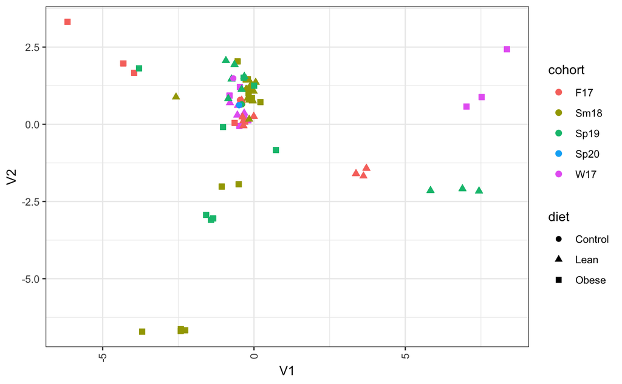

```r
#Manhattan distance (L1 norm)
mfit <- cmdscale(as.dist(man), eig=TRUE, k=2)
mfit2 = as.data.frame(mfit$points)
mfit2$name = rownames(man)
mfit2 = merge(mfit2, meta, by.x = c('name'), by.y = c('sample'))

interesting = c("1414_d06")
ggplot() +
    geom_point(data = mfit2, aes(x=V1, y= V2,shape = diet, color =cohort), size = 2) +
    #geom_text(data = mfit2 %>% filter(name %in% interesting), aes(x=V1, y= V2,label = name), hjust=0, vjust=0, angle=45) +
    PlotTheme1
```

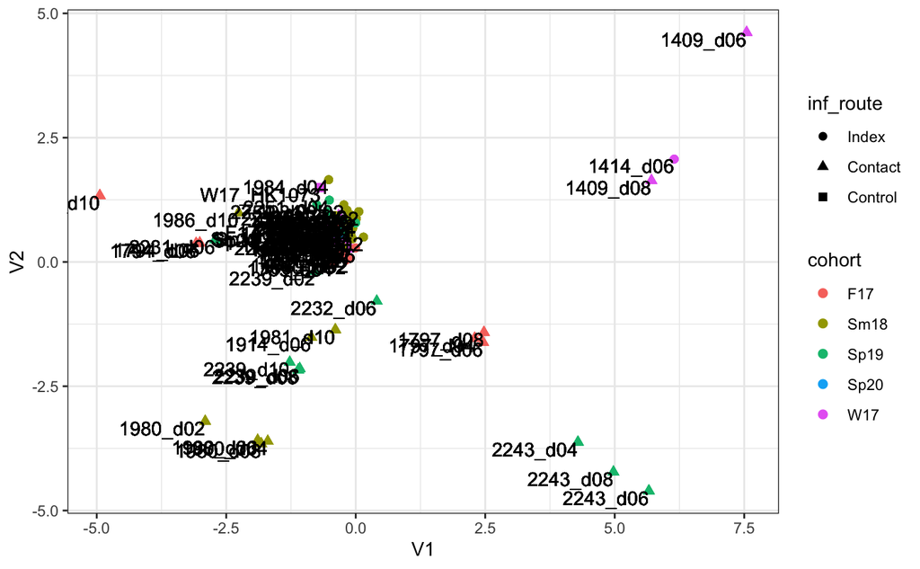

```r
#Euclidean distance (L2 norm)
efit <- cmdscale(as.dist(euc), eig=TRUE, k=2)
efit2 = as.data.frame(efit$points)
efit2$name = rownames(euc)
efit2 = merge(efit2, meta, by.x = c('name'), by.y = c('sample'))

interesting = c("1414_d06")

euc_dist = unique(efit2) %>%
  ggplot(.) +
  geom_point(aes(x=V1, y= V2,shape = inf_route, color =cohort), size = 2) +
  geom_text(data = efit2, aes(x=V1, y= V2,label = name), hjust=1, vjust=1) +
  PlotTheme2
print(euc_dist)
ggsave(euc_dist, file = "Euclidean_AllSamps.pdf", width = 7, height = 5, path = savedir)
```

```r
####
#Looking at each inf_route separately
####

ggplot() +
    geom_point(data = filter(efit2, inf_route == "Control"), aes(x=V1, y= V2,shape = diet, color =cohort), size = 2) +
    #geom_text(data = efit2 %>% filter(name %in% interesting), aes(x=V1, y= V2,label = name), hjust=0, vjust=0, angle=45) +
    PlotTheme1 +
  ggtitle("Stock only")

ggplot() +
    geom_point(data = filter(efit2, inf_route == "Index"), aes(x=V1, y= V2,shape = diet, color =cohort), size = 2) +
    #geom_text(data = efit2 %>% filter(name %in% interesting), aes(x=V1, y= V2,label = name), hjust=0, vjust=0, angle=45) +
    PlotTheme1 +
  ggtitle("Index only")

ggplot() +
    geom_point(data = filter(efit2, inf_route == "Contact"), aes(x=V1, y= V2,shape = diet, color =cohort), size = 2) +
    #geom_text(data = efit2 %>% filter(name %in% interesting), aes(x=V1, y= V2,label = name), hjust=0, vjust=0, angle=45) +
    PlotTheme1 +
  ggtitle("Contact only")
```

[output not shown]

END OF KATE 03/03 CODE

```r
red_meta = select(meta, sample,cohort,ferretID,DPI,inf_route,diet)
```

Setting up dataframe for Manhattan distances (L1 norm)

```r
man_df = as.data.frame(man)
man_df$sample = rownames(man_df)

man_long = man_df %>%
  pivot_longer(!sample, names_to = c("comp"), values_to = "dist")
man_long = man_long[!duplicated(man_long), ] %>% droplevels()

#adding metadata for first ferret in comparison
man_long_m = merge(red_meta, man_long, by = c("sample"))
man_long_m = man_long_m[!duplicated(man_long_m), ] %>% droplevels()

#adding metadata for second ferret in comparison
man_long = merge(red_meta, man_long_m, by.x = c("sample"), by.y = c("comp"))
man_long = man_long[!duplicated(man_long), ] %>% droplevels()
```

Setting up dataframe for Euclidian distances (L2 norm)

```r
euc_df = as.data.frame(euc)
euc_df$sample = rownames(euc_df)

euc_long = euc_df %>%
  pivot_longer(!sample, names_to = c("comp"), values_to = "dist")
euc_long = euc_long[!duplicated(euc_long), ] %>% droplevels()

#adding metadata for first ferret in comparison
euc_long_m = merge(red_meta, euc_long, by = c("sample"))
euc_long_m = euc_long_m[!duplicated(euc_long_m), ] %>% droplevels()

#adding metadata for second ferret in comparison
euc_long = merge(red_meta, euc_long_m, by.x = c("sample"), by.y = c("comp"))
euc_long = euc_long[!duplicated(euc_long), ] %>% droplevels()
```

```r
L1_stock_index = ggplot(filter(man_long, inf_route.x == "Control" &
                inf_route.y == "Index" &
                cohort.x == cohort.y)) +
  geom_boxplot(aes(x = diet.y, y = dist), outlier.shape =  NA, width = 0.5) +
  geom_jitter(aes(x = diet.y, y = dist, group = diet.y, color = diet.y), width = 0.1) +
  facet_grid(~DPI.y,scales = 'free', space ='free') +
  ggtitle("L1-norm between index samples and stock") +
  xlab("Diet of index ferret") +
  ylab("L1-norm (Man. distance)") +
  PlotTheme1 +
  DietcolScale
print(L1_stock_index)
ggsave("L1_stock_index.pdf",L1_stock_index,path = savedir)

L2_stock_index = ggplot(filter(euc_long, inf_route.x == "Control" &
                                 inf_route.y == "Index" &
                                 cohort.x == cohort.y &
                                 DPI.y %in% c("d02","d04","d06"))) +
  geom_boxplot(aes(x = diet.y, y = dist), outlier.shape =  NA, width = 0.5) +
  geom_jitter(aes(x = diet.y, y = dist, group = diet.y, color = diet.y), width = 0.1) +
  facet_grid(~DPI.y,scales = 'free', space ='free') +
  ggtitle("L2-norm between index samples and stock") +
  xlab("Diet of index ferret") +
  ylab("L2-norm distance to stock") +
  #ylim(0,5) +
  PlotTheme1 +
  DietcolScale
print(L2_stock_index)
ggsave("L2_stock_index.pdf",L2_stock_index,path = savedir)

euc_long_move = filter(euc_long, inf_route.x == "Control" &
                                 inf_route.y == "Index" &
                                 cohort.x == cohort.y &
                                 DPI.y %in% c("d02","d04","d06"))
write.csv(euc_long_move, "L2_norm_distances.csv", row.names = FALSE)
```

[output not shown]

```r
# T tests
ob = filter(man_long, inf_route.x == "Control" & inf_route.y == "Index" &
                  cohort.x == cohort.y &
                  diet.y == "Lean" & DPI.y == "d06")
ln = filter(man_long, inf_route.x == "Control" & inf_route.y == "Index" &
                  cohort.x == cohort.y &
                  diet.y == "Obese" & DPI.y == "d06")
t.test(ob$dist,ln$dist)
```

[output not shown]

```r
man_long_pair = merge(man_long, pairs, by.x = c("ferretID.x"), by.y = c("ferretID"))
man_long_p = merge(man_long_pair, pairs, by.x = c("ferretID.y"), by.y = c("ferretID"))
```

Still need to get these below to make sense

Comparing

```r
stock_index = filter(man_long,
                     inf_route.x == "Control" &
                       inf_route.y == "Index" &
                       cohort.x == cohort.y) %>%
  mutate(cat = "Stock -> Index", group = "Stock") %>%
  mutate(pair_numbers.x = NA,
         pair_diets.x = NA,
         pair_numbers.y = NA,
         pair_diets.y = NA) %>%
  select(-c("group"))

index_contact_pairs = filter(man_long_p,
                             inf_route.x == "Index" &
                               inf_route.y == "Contact" &
                               pair_numbers.x == pair_numbers.y) %>%
  mutate(cat = "Index -> Contact (Pairs)") %>%
# 10 LN -> LN, 2 LN -> OB, 22 OB -> OB
  filter(cat != "LN>OB")

index_contact_notpairs = filter(man_long_p,
                                inf_route.x == "Index" &
                                  inf_route.y == "Contact" &
                                  pair_numbers.x != pair_numbers.y) %>%
  mutate(cat = "Index -> Contact (Not Pairs)")
index_contact_notpairs_lean = filter(index_contact_notpairs, diet.x == "Lean" & diet.y == "Lean") # only considering between lean ferrets
index_contact_notpairs_obese = filter(index_contact_notpairs, diet.x == "Obese" & diet.y == "Obese") # only considering between obese

index_contact_notpairs = rbind(index_contact_notpairs_lean, index_contact_notpairs_obese)

man_comps = rbind(stock_index, index_contact_pairs, index_contact_notpairs)
man_comps$cat = factor(man_comps$cat, levels = c("Stock -> Index","Index -> Contact (Pairs)","Index -> Contact (Not Pairs)"))
```

```r
Transmission_GenDist = ggplot(man_comps) +
  geom_boxplot(aes(x = cat, y = dist, color = diet.y), outlier.shape =  NA, width = 0.5) +
  #geom_jitter(aes(x = cat, y = dist, group = diet.y, color = diet.y), width = 0.1) +
  ggtitle("L1-norm between index samples and stock") +
  xlab("Comparison") +
  ylab("L1-norm (Man. distance)") +
  PlotTheme1 +
  DietcolScale +
  theme(axis.text.x = element_text(angle = 0))
print(Transmission_GenDist)
ggsave(Transmission_GenDist, file = "Transmission_GenDist.pdf", path = savedir)
```

[output not shown]

```r
LN_LN = filter(man_long_p, inf_route.x == "Index" & inf_route.y == "Contact" &
                 pair_numbers.x == pair_numbers.y & pair_diets.x == "LN>LN") %>%
  mutate(cat = "Lean -> Lean Pairs")

OB_OB = filter(man_long_p, inf_route.x == "Index" & inf_route.y == "Contact" &
                 pair_numbers.x == pair_numbers.y & pair_diets.x == "OB>OB") %>%
  mutate(cat = "Obese -> Obese Pairs")

man_comps2 = rbind(stock_index, LN_LN, OB_OB, index_contact_notpairs)
man_comps2$cat = factor(man_comps2$cat, levels = c("Stock -> Index",
                                                 "Lean -> Lean Pairs","Obese -> Obese Pairs",
                                                 "Index -> Contact (Not Pairs)"))

Man_plot2 = ggplot(man_comps2) +
  geom_boxplot(aes(x = cat, y = dist, color = diet.y), outlier.shape =  NA, width = 0.5) +
#  geom_jitter(aes(x = cat, y = dist, group = diet.y, color = diet.y), width = 0.1) +
  ggtitle("L1-norm between index samples and stock") +
  xlab("Comparison") +
  ylab("L1-norm (Man. distance)") +
  PlotTheme1 +
  DietcolScale
print(Man_plot2)
ggsave("Man_plot2.pdf", Man_plot2, width = 10, height = 5, path = savedir)
```

[output not shown]

```r
LnLnPairs = filter(man_comps2, cat == "Lean -> Lean Pairs")
ObObPairs = filter(man_comps2, cat == "Obese -> Obese Pairs")
t.test(LnLnPairs$dist, ObObPairs$dist)

ObOb_NotPairs = filter(man_comps2, cat == "Index -> Contact (Not Pairs)" & diet.x == "Obese" & diet.y == "Obese")
ObObPairs = filter(man_comps2, cat == "Obese -> Obese Pairs")
t.test(ObOb_NotPairs$dist, ObObPairs$dist)
```

[output not shown]

Add transmission data #compare lean -> lean transmission #compare d02 index -> all contact time points (do the contacts diverge from their donors over time) #compare last time point index - last time point contact